# Season Finale

Stats Corner

12/26/2015

## A New Points Record

RJ set a new points record against Hartman in the toilet bowl semi-final. I thought he was a shoe-in for last place this year. His team stinks. But he shattered Hartman’s record against Hartman! That should teach Hartman never to set records again. So here is what the updated leaderboard looks like for most points in a game:

| Owner | Team | Year | Week | Points |
| --- | --- | --- | --- | --- |
| Thieneman | 12.5 PSI | 2015 | R2 | 192.6 |
| Hartman | Name Your C. Johnson | 2015 | 03 | 182.6 |
| Shokunbi | Team Shokunbi | 2014 | 13 | 182.0 |
| Skrzyszewski | Oozing With Machismo | 2013 | 13 | 181.5 |
| Harrington | Cameron’s Cuties | 2011 | 13 | 175.1 |
| Hartman | Peter Pan’s Poor Nanna | 2013 | 02 | 173.0 |
| Skrzyszewski | Oozing With Machismo | 2013 | 06 | 171.5 |
| Regan | Losman’s Gamblers | 2009 | 06 | 171.0 |
| Ready | Detroit Ride Or Die | 2013 | R2 | 170.8 |
| Harrington | Cameron’s Cuties | 2015 | 02 | 169.6 |

Aside from the gaudy point total, the surprising thing here is who is setting the record. It’s RJ and his 12.5 PSI in what has quickly become a dated reference for a fantasy football team name. RJ was in contention for setting the all-time season low point total until a few big weeks at the end pulled him out of it.

How can we square this nearly historically bad team with a points record? Let’s consider the percentage of a season’s total points achieved in each game. If you score roughly the same amount each week, you’d score about 7% or 8% of your season’s point total in a given week. Due to not having played Round 3 this year yet, and some Round 1 BYE teams with non reported scores from early in league history, I took the percentage of points each game counted toward season totals for Weeks 1-13 and Round 2. In the below graph, each dot represents one of 1,148 games played and how much of that owner’s season point total that game was responsible for. So how big of an outlier was RJ last week? See for yourself:

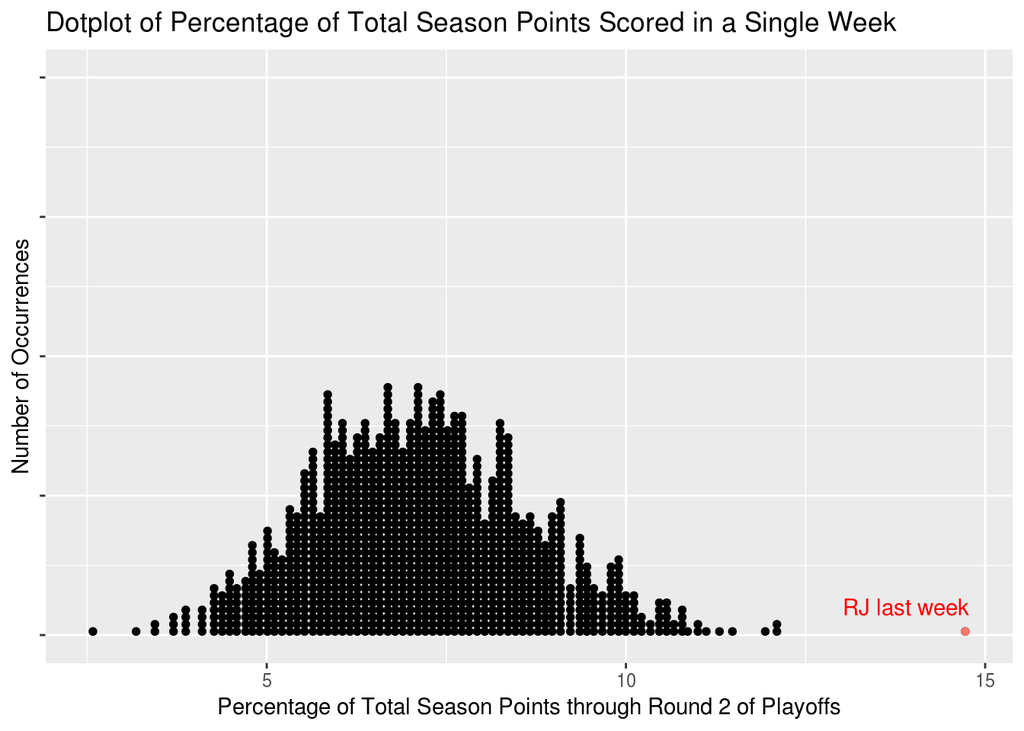

Hartman does now!!

## An Update on Playoff Probabilities

[Several weeks ago](http://rpubs.com/StatsCorner/134691) I posted some playoff odds for each team. As a check, I cross-referenced previous years’ predictions under the same methodology. I postulated that my scoring was better than random guessing, if you score by how many teams who were the most likely to finish in a given place actually earned that place. Most of my scores for each were 2/12 or 3/12. Turns out my method is no better than random guessing under similar constraints (seeds 7-12 finish in place 7-12, 1 and 2 seeds must finish in 1st-4th place).

Rather than calculate it directly I simulated data in order to determine, that, even randomly assigning teams to places the most likely outcome is to get two right! (27% of the time). Anyway, next year I commit to better methodology and better validation before I post something. Clunky and inefficient R code is [here](https://gist.github.com/johnckane/21ba25656e20033f2035) if you’d like to see the details of the calculation/simulation.

## Farewell Ola

As many of you saw, Ola announced his retirement from fantasy football last weekend. Suprising most everyone, I would say it was a little Barry Sanders-ish. But let’s not get ahead of ourselves, it’s more Ricky Williams-ish.

I’m giving Ola a proper Stats Corner send-off. Many are wondering if he’s riding off into the sunset at the ripe old age of 28. But

1. You have to win your last game in order to ride off into the sunset.
2. He doesn’t have anything to ride off in. [Remember?](https://www.youtube.com/watch?feature=player_detailpage&v=V2zvwEMYFjo#t=820)

Ola, this is your fantasy life:

- 2013 Champion
- Career 53-36-2 record
  - 53 wins are most by any owner
  - 0.582 winning percentage is #2 all-time (Olson)
- Career 0.576 Proportional Wins percentage is #3 all-time (Ready, Olson)
- One time holder of record for most points in a single game (182.0, 2014 Week 13)
- Record holder for biggest blow-out win. Defeated Taking this super seriously 157.0-42.6 in Week 7, 2011 for a margin of victory of 114.4.
- Single season points record (1615.2, 2011)
- 5 playoff appearances in 7 seasons. Regan has just as many, only Ready has more (6)
- 2 career playoff byes. Same as Ready and Higdon. Regan has 3
- League leading 38 trades made (Olson on his heels with 34)
- Countless offers made, rejected outright, laughed at and tolerated

So long, Ola. This league will miss you.